# UC Police versus Librarian Payroll, 2011-2024: Title-Summary Estimate Comparison

Robert J. Dellinger

March 31, 2026

This report is the repository’s over-time police-versus-librarian comparison branch. It uses Transparent California University of California job-title-summary pages to reconstruct annual payroll estimates for broad police and librarian title-series cohorts, then checks the police estimate branch against the exact person-level police series produced elsewhere in the repository.

> Interpretive note: this report is built from Transparent California title-summary pages, not person-level payroll records (Transparent California 2026c). Its headline totals are reconstructed annual payroll estimates in nominal dollars, not exact payroll transactions or staffing counts, and the latest `2024` year remains a latest-available snapshot rather than a finalized University of California census (Transparent California 2026b).

## Comparison overview

The objective is to build a publication-quality, reusable University of California over-time comparison between police payroll and broad librarian-series payroll using reconstructed annual payroll estimates from the public Transparent California job-title summary pages and the repository’s documented librarian title crosswalk.

### Source basis

The workflow uses Transparent California’s annual University of California job-title summary pages for `2011-2024` (Transparent California 2026a, 2026c), the latest-available 2024 University of California agency page that is still marked in progress (Transparent California 2026b), the exact police person-level series produced elsewhere in this repository for validation (Transparent California 2026a), and the repository’s cleaned 2024 librarian title crosswalk to audit current librarian title strings against the title matches already validated in the person-level workflow. The title-summary source and the police validation source remain analytically distinct throughout the report.

### Source documentation and cohort definition

Transparent California’s job-title summary pages report `Count`, `Avg Regular pay`, `Avg Overtime pay`, `Avg Other pay`, `Avg Total pay`, `Avg Benefits`, and `Avg Total pay & benefits` for each title-year combination (Transparent California 2026c). Those pages also note that the averages are designed to capture only those who have worked a full year and that part-time, seasonal, and partial-year cases are excluded from those averages (Transparent California 2026c). Because of that note, this script treats title-summary payroll totals as reconstructed annual payroll estimates rather than exact audited payroll sums. The librarian side of the comparison is defined as a broad librarian-series cohort built from observed title-summary strings that contain `LIBRARIAN`, including university, law, associate, assistant, career, potential-career, non-represented, temporary, and visiting librarian titles. The repository’s 2024 librarian crosswalk is used only as an audit aid for current title matching, while the actual over-time inclusion rule is the explicit title crosswalk written by this script. The resulting over-time figures are nominal dollars, not inflation-adjusted dollars.

### Estimation and validation logic

The workflow treats each year as a separate repeated cross-section rather than averaging workers across years. For each title `t` in year `y`, the title-summary pages provide a worker count and an average compensation value. The workflow therefore constructs estimated annual payroll by title and then sums those title-level estimates within each cohort:

- `estimated_title_total_pay_(t,y) = count_(t,y) * avg_total_pay_(t,y)`
- `estimated_group_total_pay_y = Σ estimated_title_total_pay_(t,y)` for all titles `t` in the cohort
- `police_share_of_librarian_payroll_y = estimated_police_total_pay_y / estimated_librarian_total_pay_y`
- `librarian_payroll_multiple_of_police_y = estimated_librarian_total_pay_y / estimated_police_total_pay_y`
- `average_librarian_payroll_equivalents_y = estimated_police_total_pay_y / weighted_mean_librarian_total_pay_y`

Because the title-summary pages are not person-level payroll extracts, the workflow validates the police title-summary estimates against the exact police person-level totals from the repository’s police series. Those validation gaps are reported directly and the librarian totals remain labeled as reconstructed annual payroll estimates rather than exact payroll totals. This makes the report a title-summary estimate comparison with a person-level validation layer, not a direct census of payroll transactions.

## Setup and load packages

This section loads helper functions, packages, and project paths.

```r
knitr::opts_chunk$set(echo = TRUE, warning = FALSE, message = FALSE)

utility_path <- if (file.exists("scripts/functions/uc_salary_utils.R")) {
  "scripts/functions/uc_salary_utils.R"
} else {
  "functions/uc_salary_utils.R"
}

source(utility_path)
uc_salary_load_packages()

analysis_start_year <- 2011L
year_status <- uc_salary_get_agency_year_status(agency_slug = "university-of-california")
analysis_end_year <- year_status$current_page_year[[1]]
analysis_years <- seq.int(analysis_start_year, analysis_end_year)
series_stub <- paste0("uc_police_vs_librarian_", analysis_start_year, "_", analysis_end_year)

police_detail_input <- uc_salary_path(
  "data",
  "processed",
  paste0("uc_police_spending_", analysis_start_year, "_", analysis_end_year, "_detail.csv")
)
librarian_crosswalk_input <- uc_salary_path("data", "processed", "uc_salary_2024_title_crosswalk.csv")

title_summary_detail_output <- uc_salary_path("data", "processed", paste0(series_stub, "_title_summary_detail.csv"))
title_group_output <- uc_salary_path("outputs", "tables", paste0(series_stub, "_title_group_reference.csv"))
annual_output <- uc_salary_path("outputs", "tables", paste0(series_stub, "_annual_summary.csv"))
comparison_output <- uc_salary_path("outputs", "tables", paste0(series_stub, "_comparison_summary.csv"))
validation_output <- uc_salary_path("outputs", "tables", paste0(series_stub, "_police_validation.csv"))
scrape_manifest_output <- uc_salary_path("outputs", "logs", "qa", paste0(series_stub, "_scrape_manifest.csv"))
qa_output <- uc_salary_path("outputs", "logs", "qa", paste0(series_stub, "_qa_summary.csv"))
figure_manifest_output <- uc_salary_path("outputs", "logs", "qa", paste0(series_stub, "_figure_manifest.csv"))

uc_salary_ensure_directory(dirname(title_summary_detail_output))
uc_salary_ensure_directory(dirname(title_group_output))
uc_salary_ensure_directory(dirname(scrape_manifest_output))
```

## Time-window and input validation for the title-summary comparison

These checks matter because the title-summary estimate comparison is only defensible if the latest-available UC year is identified correctly, the exact police validation file exists, and the current librarian crosswalk is available as an audit aid.

```r
stopifnot(!is.na(analysis_end_year))
stopifnot(analysis_end_year >= analysis_start_year)
stopifnot(length(analysis_years) > 0)
stopifnot(file.exists(police_detail_input))
stopifnot(file.exists(librarian_crosswalk_input))

librarian_crosswalk <- readr::read_csv(librarian_crosswalk_input, show_col_types = FALSE)
current_librarian_title_reference <- librarian_crosswalk %>%
  dplyr::filter(analysis_cohort == "Librarians") %>%
  dplyr::mutate(
    current_2024_title_job_code = dplyr::na_if(uc_title_job_code, "NA"),
    current_2024_cto_name = dplyr::na_if(uc_cto_name, "NA"),
    current_2024_title_reference_match = title_reference_match %in% c(TRUE, "TRUE")
  ) %>%
  dplyr::select(
    job_title_clean,
    current_2024_title_job_code,
    current_2024_cto_name,
    current_2024_title_reference_match
  ) %>%
  dplyr::distinct(job_title_clean, .keep_all = TRUE)

stopifnot(nrow(current_librarian_title_reference) > 0)

validation_summary <- tibble::tibble(
  validation_check = c(
    "Current Transparent California UC page year",
    "Current page marked as in progress",
    "Latest available year used in this script",
    "First year used in this script",
    "Number of years in the comparison series",
    "Exact police detail file available",
    "Current librarian crosswalk file available",
    "Current librarian crosswalk rows available"
  ),
  validation_result = c(
    year_status$current_page_year[[1]],
    year_status$data_collection_in_progress[[1]],
    analysis_end_year,
    analysis_start_year,
    length(analysis_years),
    file.exists(police_detail_input),
    file.exists(librarian_crosswalk_input),
    nrow(current_librarian_title_reference)
  )
)

knitr::kable(validation_summary)
```

| validation_check | validation_result |
| --- | --- |
| Current Transparent California UC page year | 2024 |
| Current page marked as in progress | 1 |
| Latest available year used in this script | 2024 |
| First year used in this script | 2011 |
| Number of years in the comparison series | 14 |
| Exact police detail file available | 1 |
| Current librarian crosswalk file available | 1 |
| Current librarian crosswalk rows available | 22 |

## Title-summary inputs and librarian cohort rule

This section documents the planned yearly title-summary inputs and the broad librarian-series rule that defines the comparison cohort. These objects are design and audit inputs: they explain what the over-time comparison will include before any annual payroll estimates are constructed.

### Planned title-summary inputs and librarian inclusion rule

The first table lists the yearly raw title-summary inputs. The second states the broad librarian-series rule. The third uses the 2024 crosswalk only as a current audit aid for observed librarian title matching.

```r
planned_input_manifest <- tibble::tibble(
  year = analysis_years,
  raw_file = file.path(
    uc_salary_path("data", "raw", "transparent_california"),
    as.character(analysis_years),
    paste0("tc_", analysis_years, "_job_title_summary.csv")
  )
) %>%
  dplyr::mutate(raw_file_exists = file.exists(raw_file))

librarian_series_rules <- tibble::tibble(
  analysis_cohort = "Librarians",
  include_regex = "LIBRARIAN",
  exclude_regex = NA_character_,
  rule_note = paste(
    "The librarian comparison uses a broad librarian-series payroll cohort built from every observed UC title-summary",
    "string that contains `LIBRARIAN`, including university, law, associate, assistant, career, potential-career,",
    "non-represented, temporary, and visiting librarian titles."
  )
)

planned_input_manifest %>%
  dplyr::mutate(raw_file = uc_salary_relpath(raw_file)) %>%
  knitr::kable()
```

| year | raw_file | raw_file_exists |
| --- | --- | --- |
| 2011 | data/raw/transparent_california/2011/tc_2011_job_title_summary.csv | TRUE |
| 2012 | data/raw/transparent_california/2012/tc_2012_job_title_summary.csv | TRUE |
| 2013 | data/raw/transparent_california/2013/tc_2013_job_title_summary.csv | TRUE |
| 2014 | data/raw/transparent_california/2014/tc_2014_job_title_summary.csv | TRUE |
| 2015 | data/raw/transparent_california/2015/tc_2015_job_title_summary.csv | TRUE |
| 2016 | data/raw/transparent_california/2016/tc_2016_job_title_summary.csv | TRUE |
| 2017 | data/raw/transparent_california/2017/tc_2017_job_title_summary.csv | TRUE |
| 2018 | data/raw/transparent_california/2018/tc_2018_job_title_summary.csv | TRUE |
| 2019 | data/raw/transparent_california/2019/tc_2019_job_title_summary.csv | TRUE |
| 2020 | data/raw/transparent_california/2020/tc_2020_job_title_summary.csv | TRUE |
| 2021 | data/raw/transparent_california/2021/tc_2021_job_title_summary.csv | TRUE |
| 2022 | data/raw/transparent_california/2022/tc_2022_job_title_summary.csv | TRUE |
| 2023 | data/raw/transparent_california/2023/tc_2023_job_title_summary.csv | TRUE |
| 2024 | data/raw/transparent_california/2024/tc_2024_job_title_summary.csv | TRUE |

```r
librarian_series_rules %>%
  knitr::kable()
```

| analysis_cohort | include_regex | exclude_regex | rule_note |
| --- | --- | --- | --- |
| Librarians | LIBRARIAN | NA | The librarian comparison uses a broad librarian-series payroll cohort built from every observed UC title-summary string that contains `LIBRARIAN`, including university, law, associate, assistant, care… |

```r
current_librarian_title_reference %>%
  dplyr::count(current_2024_cto_name, current_2024_title_reference_match, sort = TRUE) %>%
  knitr::kable()
```

| current_2024_cto_name | current_2024_title_reference_match | n |
| --- | --- | --- |
| LIBRARIAN | TRUE | 13 |
| ASSOC & ASST UNIVERSITY LIBRARIAN | TRUE | 4 |
| NA | FALSE | 3 |
| UNIVERSITY LIBRARIAN | TRUE | 1 |
| VISITING LIBRARIAN | TRUE | 1 |

## Construction of annual payroll estimates and validation tables

This section scrapes or reuses yearly title-summary pages, defines the police and librarian cohorts, validates the title-summary police estimates against the exact police series, and writes publication-ready figures and tables. Analytically, it proceeds in four steps: collecting yearly title-summary inputs, defining the librarian and police title-series cohorts, constructing annual payroll estimates, and attaching the exact police validation layer before exporting the figures and tables.

```r
yearly_title_summary_results <- purrr::map(
  analysis_years,
  function(year_value) {
    raw_year_directory <- uc_salary_path("data", "raw", "transparent_california", as.character(year_value))
    raw_output_path <- file.path(raw_year_directory, paste0("tc_", year_value, "_job_title_summary.csv"))

    uc_salary_ensure_directory(raw_year_directory)

    # Reuse cached yearly title-summary extracts when they already exist.
    year_title_summary <- if (file.exists(raw_output_path)) {
      cached_year_summary <- readr::read_csv(raw_output_path, show_col_types = FALSE)

      if (uc_salary_cache_is_current(cached_year_summary)) {
        cached_year_summary
      } else {
        raw_year_summary <- uc_salary_scrape_job_title_summary(
          year = year_value,
          pause_seconds = 0.10,
          verbose = TRUE
        )

        readr::write_csv(raw_year_summary, raw_output_path)
        raw_year_summary
      }
    } else {
      raw_year_summary <- uc_salary_scrape_job_title_summary(
        year = year_value,
        pause_seconds = 0.10,
        verbose = TRUE
      )

      readr::write_csv(raw_year_summary, raw_output_path)
      raw_year_summary
    }

    manifest_row <- tibble::tibble(
      year = year_value,
      raw_file = raw_output_path,
      title_rows_scraped = nrow(year_title_summary),
      unique_titles_scraped = dplyr::n_distinct(year_title_summary$job_title_clean),
      total_pages_reported = max(year_title_summary$source_total_pages, na.rm = TRUE),
      unique_pages_scraped = dplyr::n_distinct(year_title_summary$source_page),
      source_note = dplyr::first(year_title_summary$source_note)
    )

    list(data = year_title_summary, manifest = manifest_row)
  }
)

title_summary_detail <- dplyr::bind_rows(purrr::map(yearly_title_summary_results, "data"))
scrape_manifest <- dplyr::bind_rows(purrr::map(yearly_title_summary_results, "manifest"))

librarian_title_candidates <- title_summary_detail %>%
  dplyr::filter(stringr::str_detect(job_title_clean, "LIBRARIAN")) %>%
  dplyr::group_by(job_title, job_title_clean) %>%
  dplyr::summarise(
    first_year = min(year, na.rm = TRUE),
    last_year = max(year, na.rm = TRUE),
    max_worker_count = max(count, na.rm = TRUE),
    .groups = "drop"
  ) %>%
  dplyr::mutate(
    analysis_cohort = "Librarians",
    included_in_comparison = TRUE,
    comparison_note = dplyr::case_when(
      stringr::str_detect(job_title_clean, "UNIV LIBRARIAN|UNIVERSITY LIBRARIAN") ~ "Included as part of the broad librarian series; this title captures university-librarian leadership positions within library payroll.",
      stringr::str_detect(job_title_clean, "LAW LIBRARIAN") ~ "Included as part of the broad librarian series; law-library titles remain within the public-facing librarian payroll comparison.",
      stringr::str_detect(job_title_clean, "TEMP|VIS") ~ "Included as part of the broad librarian series because the title-summary pages already aim to capture full-year workers, but this title should not be read as a permanent appointment count.",
      TRUE ~ "Included as part of the broad librarian series in the police-versus-librarian comparison."
    )
  ) %>%
  dplyr::left_join(
    current_librarian_title_reference,
    by = "job_title_clean"
  )

included_librarian_titles <- librarian_title_candidates %>%
  dplyr::filter(included_in_comparison, !is.na(analysis_cohort))

comparison_title_detail <- title_summary_detail %>%
  dplyr::left_join(
    included_librarian_titles %>%
      dplyr::select(
        job_title_clean,
        analysis_cohort,
        current_2024_title_job_code,
        current_2024_cto_name,
        current_2024_title_reference_match
      ),
    by = "job_title_clean"
  ) %>%
  dplyr::mutate(
    analysis_cohort = dplyr::case_when(
      stringr::str_detect(job_title_clean, "\\bPOLICE\\b") ~ "Police",
      TRUE ~ analysis_cohort
    ),
    cohort_group = dplyr::case_when(
      analysis_cohort == "Police" ~ "Police",
      analysis_cohort == "Librarians" ~ "Librarians",
      TRUE ~ NA_character_
    )
  ) %>%
  dplyr::filter(!is.na(analysis_cohort))

annual_summary <- comparison_title_detail %>%
  dplyr::group_by(year, cohort_group, analysis_cohort) %>%
  dplyr::summarise(
    title_rows = dplyr::n(),
    workers = sum(count, na.rm = TRUE),
    estimated_regular_pay = sum(estimated_regular_pay, na.rm = TRUE),
    estimated_overtime_pay = sum(estimated_overtime_pay, na.rm = TRUE),
    estimated_other_pay = sum(estimated_other_pay, na.rm = TRUE),
    estimated_total_pay = sum(estimated_total_pay, na.rm = TRUE),
    estimated_benefits = sum(estimated_benefits, na.rm = TRUE),
    estimated_total_pay_benefits = sum(estimated_total_pay_benefits, na.rm = TRUE),
    weighted_avg_regular_pay = stats::weighted.mean(avg_regular_pay, w = count, na.rm = TRUE),
    weighted_avg_total_pay = stats::weighted.mean(avg_total_pay, w = count, na.rm = TRUE),
    weighted_avg_total_pay_benefits = stats::weighted.mean(avg_total_pay_benefits, w = count, na.rm = TRUE),
    .groups = "drop"
  ) %>%
  dplyr::arrange(year, cohort_group, analysis_cohort)

police_exact_annual <- readr::read_csv(police_detail_input, show_col_types = FALSE) %>%
  dplyr::group_by(year) %>%
  dplyr::summarise(
    exact_police_workers = dplyr::n(),
    exact_police_total_pay = sum(total_pay, na.rm = TRUE),
    exact_police_total_pay_benefits = sum(total_pay_benefits, na.rm = TRUE),
    .groups = "drop"
  )

police_validation <- annual_summary %>%
  dplyr::filter(analysis_cohort == "Police") %>%
  dplyr::transmute(
    year,
    estimated_police_workers = workers,
    estimated_police_total_pay = estimated_total_pay,
    estimated_police_total_pay_benefits = estimated_total_pay_benefits
  ) %>%
  dplyr::left_join(police_exact_annual, by = "year") %>%
  dplyr::mutate(
    worker_gap = estimated_police_workers - exact_police_workers,
    worker_gap_pct = dplyr::if_else(exact_police_workers > 0, estimated_police_workers / exact_police_workers - 1, NA_real_),
    total_pay_gap = estimated_police_total_pay - exact_police_total_pay,
    total_pay_gap_pct = dplyr::if_else(exact_police_total_pay > 0, estimated_police_total_pay / exact_police_total_pay - 1, NA_real_),
    total_pay_benefits_gap = estimated_police_total_pay_benefits - exact_police_total_pay_benefits,
    total_pay_benefits_gap_pct = dplyr::if_else(
      exact_police_total_pay_benefits > 0,
      estimated_police_total_pay_benefits / exact_police_total_pay_benefits - 1,
      NA_real_
    )
  )
```

```r
comparison_summary <- annual_summary %>%
  dplyr::filter(analysis_cohort %in% c("Police", "Librarians")) %>%
  dplyr::select(year, analysis_cohort, workers, estimated_total_pay, estimated_total_pay_benefits, weighted_avg_total_pay) %>%
  tidyr::pivot_wider(
    names_from = analysis_cohort,
    values_from = c(workers, estimated_total_pay, estimated_total_pay_benefits, weighted_avg_total_pay),
    names_sep = "__"
  ) %>%
  dplyr::arrange(year) %>%
  dplyr::mutate(
    police_share_of_librarian_payroll = `estimated_total_pay__Police` / `estimated_total_pay__Librarians`,
    librarian_payroll_multiple_of_police = `estimated_total_pay__Librarians` / `estimated_total_pay__Police`,
    average_librarian_payroll_equivalents = `estimated_total_pay__Police` / `weighted_avg_total_pay__Librarians`,
    cumulative_police_total_pay = cumsum(`estimated_total_pay__Police`),
    cumulative_librarian_total_pay = cumsum(`estimated_total_pay__Librarians`)
  )

readr::write_csv(title_summary_detail, title_summary_detail_output)
readr::write_csv(librarian_title_candidates, title_group_output)
readr::write_csv(annual_summary, annual_output)
readr::write_csv(comparison_summary, comparison_output)
readr::write_csv(police_validation, validation_output)
readr::write_csv(scrape_manifest, scrape_manifest_output)

payroll_colour_map <- c(
  "Police" = "#3A506B",
  "Librarians" = "#8B1E3F"
)

share_colour_map <- c(
  "Police as share of librarian payroll" = "#8B1E3F"
)

equivalent_colour_map <- c(
  "Average librarian payrolls" = "#D1495B"
)

start_share_label <- scales::label_percent(accuracy = 1)(
  comparison_summary$police_share_of_librarian_payroll[comparison_summary$year == analysis_start_year][[1]]
)
end_share_label <- scales::label_percent(accuracy = 1)(
  comparison_summary$police_share_of_librarian_payroll[comparison_summary$year == analysis_end_year][[1]]
)
min_share_label <- scales::label_percent(accuracy = 1)(min(comparison_summary$police_share_of_librarian_payroll, na.rm = TRUE))
max_share_label <- scales::label_percent(accuracy = 1)(max(comparison_summary$police_share_of_librarian_payroll, na.rm = TRUE))

payroll_comparison_plot_data <- comparison_summary %>%
  dplyr::transmute(
    year,
    Police = `estimated_total_pay__Police`,
    Librarians = `estimated_total_pay__Librarians`
  ) %>%
  tidyr::pivot_longer(
    cols = c(Police, Librarians),
    names_to = "comparison_group",
    values_to = "estimated_total_pay"
  )

share_plot_data <- comparison_summary %>%
  dplyr::transmute(
    year,
    `Police as share of librarian payroll` = police_share_of_librarian_payroll
  ) %>%
  tidyr::pivot_longer(
    cols = c(`Police as share of librarian payroll`),
    names_to = "share_measure",
    values_to = "share_value"
  )

equivalent_plot_data <- comparison_summary %>%
  dplyr::transmute(
    year,
    `Average librarian payrolls` = average_librarian_payroll_equivalents
  ) %>%
  tidyr::pivot_longer(
    cols = c(`Average librarian payrolls`),
    names_to = "equivalent_measure",
    values_to = "equivalent_value"
  )

plot_police_vs_librarian_payroll <- ggplot2::ggplot(
  payroll_comparison_plot_data,
  ggplot2::aes(x = year, y = estimated_total_pay, colour = comparison_group)
) +
  ggplot2::geom_line(linewidth = 1.3) +
  ggplot2::geom_point(size = 2.6) +
  ggplot2::geom_text(
    data = payroll_comparison_plot_data %>% dplyr::filter(year == analysis_end_year),
    ggplot2::aes(
      label = paste0(comparison_group, ": ", scales::label_dollar(scale = 1e-6, suffix = "M", accuracy = 0.1)(estimated_total_pay))
    ),
    hjust = 0,
    nudge_x = 0.25,
    size = 3.2,
    show.legend = FALSE
  ) +
  ggplot2::scale_colour_manual(values = payroll_colour_map) +
  ggplot2::scale_x_continuous(breaks = analysis_years, expand = ggplot2::expansion(mult = c(0.01, 0.18))) +
  ggplot2::scale_y_continuous(
    labels = scales::label_dollar(scale_cut = scales::cut_short_scale()),
    expand = ggplot2::expansion(mult = c(0.02, 0.10))
  ) +
  ggplot2::labs(
    title = uc_salary_wrap_text(paste0("Estimated annual police and librarian payroll, ", analysis_start_year, "-", analysis_end_year), 62),
    subtitle = uc_salary_wrap_text("Nominal annual payroll estimates reconstructed from Transparent California title counts x annual averages for broad police and librarian title-series cohorts.", 105),
    x = NULL,
    y = "Estimated annual total pay",
    colour = NULL,
    caption = uc_salary_wrap_text("Source type: Transparent California job-title-summary payroll estimates. These are reconstructed annual estimates, not exact person-level payroll totals.", 135)
  ) +
  uc_salary_theme() +
  ggplot2::theme(axis.text.x = ggplot2::element_text(angle = 45, hjust = 1))

plot_police_payroll_share <- ggplot2::ggplot(
  share_plot_data,
  ggplot2::aes(x = year, y = share_value, colour = share_measure)
) +
  ggplot2::geom_line(linewidth = 1.3) +
  ggplot2::geom_point(size = 2.4) +
  ggplot2::geom_text(
    data = share_plot_data %>% dplyr::filter(year == analysis_end_year),
    ggplot2::aes(label = scales::label_percent(accuracy = 0.1)(share_value)),
    hjust = 0,
    nudge_x = 0.25,
    size = 3.2,
    show.legend = FALSE
  ) +
  ggplot2::scale_colour_manual(values = share_colour_map) +
  ggplot2::scale_x_continuous(breaks = analysis_years, expand = ggplot2::expansion(mult = c(0.01, 0.18))) +
  ggplot2::scale_y_continuous(
    labels = scales::label_percent(accuracy = 1),
    expand = ggplot2::expansion(mult = c(0, 0.12))
  ) +
  ggplot2::labs(
    title = uc_salary_wrap_text(paste0("Estimated police payroll as a share of estimated librarian payroll, ", analysis_start_year, "-", analysis_end_year), 62),
    subtitle = uc_salary_wrap_text(glue::glue("The police-to-librarian payroll ratio ranged from about {min_share_label} to {max_share_label} and ended at {end_share_label} in {analysis_end_year}."), 105),
    x = NULL,
    y = "Police payroll share",
    colour = NULL,
    caption = uc_salary_wrap_text("Source type: title-summary payroll estimates in nominal dollars. Police estimates are cross-checked against the exact person-level police series elsewhere in the repository.", 135)
  ) +
  uc_salary_theme() +
  ggplot2::theme(axis.text.x = ggplot2::element_text(angle = 45, hjust = 1))
```

```r
plot_librarian_equivalent_payrolls <- ggplot2::ggplot(
  equivalent_plot_data,
  ggplot2::aes(x = year, y = equivalent_value, colour = equivalent_measure)
) +
  ggplot2::geom_line(linewidth = 1.3) +
  ggplot2::geom_point(size = 2.4) +
  ggplot2::geom_text(
    data = equivalent_plot_data %>% dplyr::filter(year == analysis_end_year),
    ggplot2::aes(label = scales::number(equivalent_value, accuracy = 1)),
    hjust = 0,
    nudge_x = 0.25,
    size = 3.2,
    show.legend = FALSE
  ) +
  ggplot2::scale_colour_manual(values = equivalent_colour_map) +
  ggplot2::scale_x_continuous(breaks = analysis_years, expand = ggplot2::expansion(mult = c(0.01, 0.18))) +
  ggplot2::scale_y_continuous(expand = ggplot2::expansion(mult = c(0, 0.12))) +
  ggplot2::labs(
    title = uc_salary_wrap_text(paste0("Estimated police payroll expressed as same-year average librarian payroll equivalents, ", analysis_start_year, "-", analysis_end_year), 62),
    subtitle = uc_salary_wrap_text("Annual police estimated total pay divided by the same-year weighted mean librarian avg_total_pay from the title-summary pages.", 105),
    x = NULL,
    y = "Equivalent same-year average payrolls",
    colour = NULL,
    caption = uc_salary_wrap_text("Interpret this as a payroll-equivalent ratio from title-summary estimates, not as librarian headcount, authorized positions, or hiring capacity.", 135)
  ) +
  uc_salary_theme() +
  ggplot2::theme(axis.text.x = ggplot2::element_text(angle = 45, hjust = 1))

figure_manifest <- tibble::tibble(
  figure = c(
    "Estimated annual police versus librarian payroll",
    "Police payroll share of librarian payroll",
    "Librarian payroll-equivalent counts for police payroll"
  ),
  output_path = c(
    uc_salary_save_plot(plot_police_vs_librarian_payroll, paste0(series_stub, "_annual_estimated_payroll.png"), width = 12.5, height = 8),
    uc_salary_save_plot(plot_police_payroll_share, paste0(series_stub, "_payroll_share.png"), width = 12.5, height = 8),
    uc_salary_save_plot(plot_librarian_equivalent_payrolls, paste0(series_stub, "_librarian_equivalent_payrolls.png"), width = 12.5, height = 8)
  )
)

readr::write_csv(figure_manifest, figure_manifest_output)
```

## Final estimate tables and figures

This section reviews the finished annual comparison tables and the police-validation results before the report concludes, then renders the saved figures inline so the HTML output shows the estimated series directly.

### Annual estimated-series tables

These tables show the annual title-summary payroll estimates and the police validation gaps that anchor the over-time comparison methodologically.

```r
annual_summary %>%
  dplyr::filter(analysis_cohort %in% c("Police", "Librarians")) %>%
  dplyr::select(year, analysis_cohort, workers, estimated_total_pay, estimated_total_pay_benefits, weighted_avg_total_pay) %>%
  dplyr::arrange(year, analysis_cohort) %>%
  knitr::kable()
```

| year | analysis_cohort | workers | estimated_total_pay | estimated_total_pay_benefits | weighted_avg_total_pay |
| --- | --- | --- | --- | --- | --- |
| 2011 | Librarians | 627 | 46598148 | 46598148 | 74319.22 |
| 2011 | Police | 378 | 35947053 | 35947053 | 95098.02 |
| 2012 | Librarians | 978 | 76297031 | 76297031 | 78013.32 |
| 2012 | Police | 396 | 38016980 | 38016980 | 96002.47 |
| 2013 | Librarians | 942 | 77857699 | 95766094 | 82651.49 |
| 2013 | Police | 390 | 38960466 | 47369224 | 99898.63 |
| 2014 | Librarians | 936 | 79431724 | 99667125 | 84862.95 |
| 2014 | Police | 399 | 42372157 | 52224795 | 106195.88 |
| 2015 | Librarians | 932 | 81016810 | 102834562 | 86927.91 |
| 2015 | Police | 409 | 43112223 | 53489933 | 105408.86 |
| 2016 | Librarians | 965 | 84452356 | 107290203 | 87515.39 |
| 2016 | Police | 415 | 45167250 | 56142326 | 108836.75 |
| 2017 | Librarians | 986 | 88665782 | 112518767 | 89924.73 |
| 2017 | Police | 410 | 47525045 | 58777173 | 115914.74 |
| 2018 | Librarians | 970 | 89209610 | 113312414 | 91968.67 |
| 2018 | Police | 420 | 52069637 | 62818373 | 123975.33 |
| 2019 | Librarians | 900 | 87700320 | 110660156 | 97444.80 |
| 2019 | Police | 404 | 53164241 | 61756344 | 131594.66 |
| 2020 | Librarians | 973 | 100850400 | 125933501 | 103648.92 |
| 2020 | Police | 416 | 54380601 | 60835402 | 130722.60 |
| 2021 | Librarians | 907 | 96592140 | 120894172 | 106496.30 |
| 2021 | Police | 412 | 53639444 | 59942941 | 130192.83 |
| 2022 | Librarians | 870 | 96836667 | 120860038 | 111306.51 |
| 2022 | Police | 400 | 59397652 | 65751965 | 148494.13 |
| 2023 | Librarians | 837 | 97586898 | 121271905 | 116591.28 |
| 2023 | Police | 400 | 67091314 | 73917409 | 167728.29 |
| 2024 | Librarians | 887 | 105721628 | 131085813 | 119190.11 |
| 2024 | Police | 428 | 79234975 | 86971448 | 185128.45 |

```r
police_validation %>%
  dplyr::select(year, estimated_police_total_pay, exact_police_total_pay, total_pay_gap_pct) %>%
  knitr::kable()
```

| year | estimated_police_total_pay | exact_police_total_pay | total_pay_gap_pct |
| --- | --- | --- | --- |
| 2011 | 35947053 | 36204192 | -0.0071025 |
| 2012 | 38016980 | 38137430 | -0.0031583 |
| 2013 | 38960466 | 39251195 | -0.0074069 |
| 2014 | 42372157 | 42751996 | -0.0088847 |
| 2015 | 43112223 | 43471574 | -0.0082663 |
| 2016 | 45167250 | 45573824 | -0.0089212 |
| 2017 | 47525045 | 47797448 | -0.0056991 |
| 2018 | 52069637 | 52355328 | -0.0054568 |
| 2019 | 53164241 | 53806127 | -0.0119296 |
| 2020 | 54380601 | 54755793 | -0.0068521 |
| 2021 | 53639444 | 54103807 | -0.0085828 |
| 2022 | 59397652 | 59874521 | -0.0079645 |
| 2023 | 67091314 | 68170959 | -0.0158373 |
| 2024 | 79234975 | 79938707 | -0.0088034 |

### Rendered figures by estimand

The figures below are the same outputs written to `outputs/figures/`, rendered inline so the report can be read as the primary interpretive document for the title-summary comparison workflow.

### Estimated annual payroll comparison

This figure is the headline over-time comparison. It remains carefully labeled as a title-summary estimate rather than a person-level payroll census.

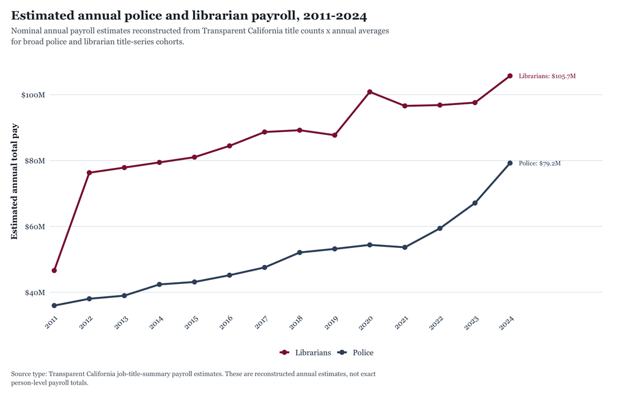

```r
plot_police_vs_librarian_payroll
```

### Police payroll share of librarian payroll

This figure expresses the same annual comparison as a ratio, which helps keep source type fixed while changing the estimand from total pay to payroll share.

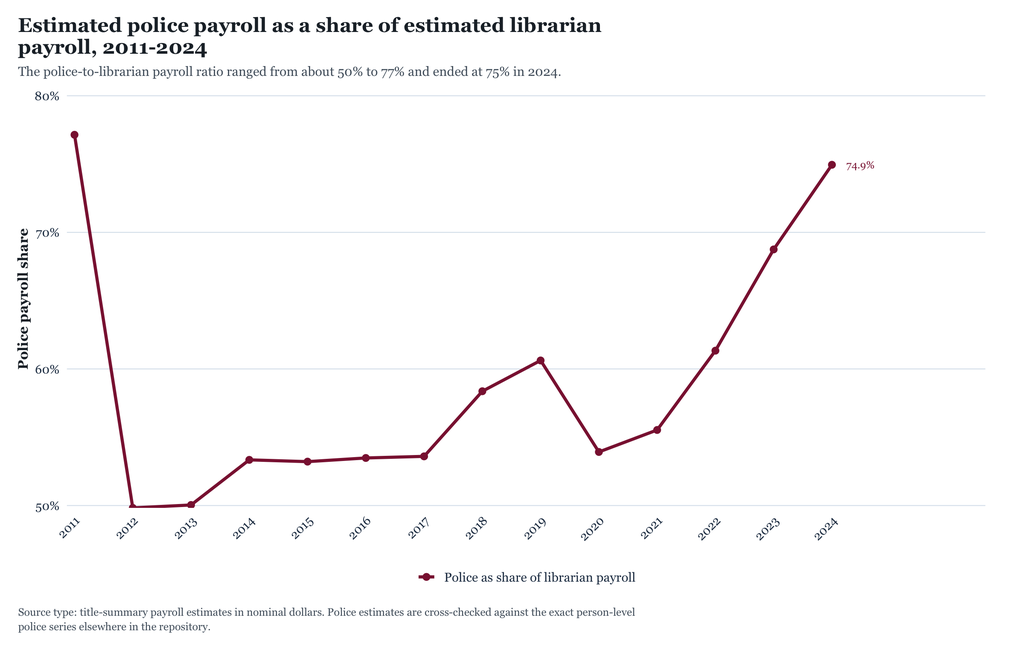

```r
plot_police_payroll_share
```

### Librarian payroll-equivalent interpretation

This figure translates police payroll into same-year average librarian payroll equivalents. It is interpretive, but it still rests on the same reconstructed nominal payroll estimates.

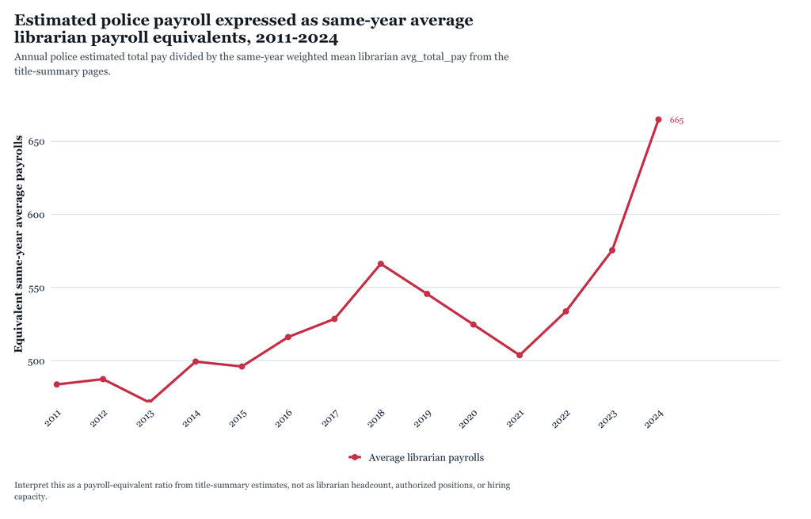

```r
plot_librarian_equivalent_payrolls
```

## Report-level validation checks

This section records the main quality checks for title coverage, validation gaps, and figure creation. Together these checks show whether the title-summary comparison remained internally consistent and whether the police validation layer stayed within expected bounds.

```r
qa_summary <- tibble::tibble(
  qa_metric = c(
    "Years analyzed",
    "Title-summary rows in comparison detail",
    "Police title rows included",
    "Included librarian observed titles",
    "Included librarian titles with current 2024 crosswalk match",
    "Maximum absolute police total-pay validation gap",
    "Mean absolute police total-pay validation gap",
    "Figures written"
  ),
  qa_value = c(
    length(analysis_years),
    nrow(comparison_title_detail),
    dplyr::n_distinct(comparison_title_detail$job_title_clean[comparison_title_detail$analysis_cohort == "Police"]),
    nrow(included_librarian_titles),
    sum(included_librarian_titles$current_2024_title_reference_match, na.rm = TRUE),
    max(abs(police_validation$total_pay_gap_pct), na.rm = TRUE),
    mean(abs(police_validation$total_pay_gap_pct), na.rm = TRUE),
    nrow(figure_manifest)
  )
)

readr::write_csv(qa_summary, qa_output)

qa_summary %>%
  knitr::kable()
```

| qa_metric | qa_value |
| --- | --- |
| Years analyzed | 14.0000000 |
| Title-summary rows in comparison detail | 579.0000000 |
| Police title rows included | 20.0000000 |
| Included librarian observed titles | 52.0000000 |
| Included librarian titles with current 2024 crosswalk match | 32.0000000 |
| Maximum absolute police total-pay validation gap | 0.0158373 |
| Mean absolute police total-pay validation gap | 0.0082047 |
| Figures written | 3.0000000 |

## Saved tables, figures, and report artifacts

This artifact registry functions as a reproducibility appendix rather than a findings table. The labels below distinguish title-summary estimate artifacts from the exact police validation table and the audit logs that explain the comparison design.

```r
export_manifest <- dplyr::bind_rows(
  tibble::tibble(
    artifact = c(
      "Processed title-summary detail for payroll estimation",
      "Observed librarian title-group reference",
      "Annual title-summary comparison summary",
      "Police-versus-librarian estimated payroll summary",
      "Police estimate-versus-exact validation table",
      "Title-summary scrape manifest",
      "Title-summary figure manifest",
      "Title-summary comparison QA summary"
    ),
    output_path = c(
      title_summary_detail_output,
      title_group_output,
      annual_output,
      comparison_output,
      validation_output,
      scrape_manifest_output,
      figure_manifest_output,
      qa_output
    )
  ),
  figure_manifest %>%
    dplyr::rename(artifact = figure)
)

export_manifest %>%
  dplyr::mutate(output_path = uc_salary_relpath(output_path)) %>%
  knitr::kable()
```

| artifact | output_path |
| --- | --- |
| Processed title-summary detail for payroll estimation | data/processed/uc_police_vs_librarian_2011_2024_title_summary_detail.csv |
| Observed librarian title-group reference | outputs/tables/uc_police_vs_librarian_2011_2024_title_group_reference.csv |
| Annual title-summary comparison summary | outputs/tables/uc_police_vs_librarian_2011_2024_annual_summary.csv |
| Police-versus-librarian estimated payroll summary | outputs/tables/uc_police_vs_librarian_2011_2024_comparison_summary.csv |
| Police estimate-versus-exact validation table | outputs/tables/uc_police_vs_librarian_2011_2024_police_validation.csv |
| Title-summary scrape manifest | outputs/logs/qa/uc_police_vs_librarian_2011_2024_scrape_manifest.csv |
| Title-summary figure manifest | outputs/logs/qa/uc_police_vs_librarian_2011_2024_figure_manifest.csv |
| Title-summary comparison QA summary | outputs/logs/qa/uc_police_vs_librarian_2011_2024_qa_summary.csv |
| Estimated annual police versus librarian payroll | outputs/figures/uc_police_vs_librarian_2011_2024_annual_estimated_payroll.png |
| Police payroll share of librarian payroll | outputs/figures/uc_police_vs_librarian_2011_2024_payroll_share.png |
| Librarian payroll-equivalent counts for police payroll | outputs/figures/uc_police_vs_librarian_2011_2024_librarian_equivalent_payrolls.png |

## Closing interpretation

This report shows a title-summary estimate comparison, not a person-level census of payroll transactions. Its strongest headline contrasts are the annual police-versus-librarian payroll estimates and the police validation gaps that bound how those estimates should be interpreted.

# Works Cited

This section is reserved for the bibliography generated from the report citations.

Transparent California. 2026a. *2011–2024 Salaries for University of California*. https://transparentcalifornia.com/salaries/university-of-california/.

Transparent California. 2026b. *2024 Salaries for University of California*. https://transparentcalifornia.com/salaries/2024/university-of-california/.

Transparent California. 2026c. *Job Title Summary for University of California*. https://transparentcalifornia.com/salaries/2024/university-of-california/job_title_summary/.